# Pipeline askoR - User Guide

Fabrice Legeai, Kevin Gazengel and Susete Alves C.

INRAE Centre Bretagne - Normandie, UMR 1349 iGEPP

26 août 2020

# 1 ABSTRACT

**AskoR** is a pipeline for the analysis of gene expression data, using edgeR. Several steps are performed: data filters (cpm method), normalize this filtered data, look at the correlation of our data, run differential expression analysis, compare contrast, GO enrichment and co-expression.  
You’ll find a test set in the **inst/extdata/input** folder. It’ll be used for the rest of the documentation. Contents of **input** folder:

- **Count matrix file**: CountsMatrix.txt **OR** Counts files per samples: files in “counts” directory *(counts.tgz)*
- **Samples file**: Samples_CountsMatrix.txt **OR** Samples_CountsFiles.txt
- **Contrasts file**: Contrasts.txt
- **Genes annotations file**: Genes_annotations.txt (optional)
- **GO annotations file**: GO_annotations.txt (optional)

**IMPORTANT :** All input files must be in a folder named **input** *(case sensitive)*.

# 2 Input files description

## 2.1 Count files

### 2.1.1 Sample count files

You have a count file **per sample**, they can be in text or csv format. In this case, you will have to fill in the **Samples** file with the path and name of the **count files** for each sample in a **“file”** column. This one can contain several columns according to the counting tools used, you will have to inform the following parameters:

- `parameters$col_genes` column number with GeneId (default 1)
- `parameters$col_counts` column number with count (default 7)
- `parameters$sep` column separator (default **“\t”** )

Example of count file:

| Geneid | Chr | Start | End | Strand | Length | Counts |
| --- | --- | --- | --- | --- | --- | --- |
| Gene_000001 | Random_Chr_001 | 1692 | 1907 | - | 215 | 0 |
| Gene_000002 | Random_Chr_001 | 6641 | 8705 | - | 2064 | 43.5 |
| Gene_000003 | Random_Chr_001 | 9228 | 9569 | - | 341 | 8 |
| Gene_000004 | Random_Chr_001 | 12009 | 13155 | - | 1146 | 781 |
| Gene_000005 | Random_Chr_001 | 15242 | 15844 | + | 602 | 16 |
| Gene_000006 | Random_Chr_001 | 16304 | 19834 | + | 3530 | 9 |
| Gene_000007 | Random_Chr_001 | 20595 | 21625 | - | 1030 | 13.83 |
| Gene_000008 | Random_Chr_001 | 22377 | 23461 | - | 1084 | 565.33 |
| **…** |  |  |  |  |  |  |

The corresponding parameters:

```r
parameters$col_genes=1
parameters$col_counts=7
parameters$sep="\t"
```

In this example column 7 contains the counts and the gene identifiers are in the first column, it’s a tabulate file so the column separator is encoded “\t”.

### 2.1.2 Counts matrix file

It is also possible to have a table, **tabulated file**, grouping the counts for each gene in each sample, in text or csv format. The **Samples** file should not contain a **file** column, you will have to fill in the name of the count file: `parameters$fileofcount`.  
Example of a count matrix, the column separator is a tabulation:

| Geneid | AC1R1 | AC1R2 | AC1R3 | BC1R1 | BC1R2 | BC1R3 | **…** |
| --- | --- | --- | --- | --- | --- | --- | --- |
| Gene_000001 | 0 | 1 | 0 | 0 | 0 | 1 | **…** |
| Gene_000002 | 43.5 | 25.33 | 31.5 | 27.5 | 29.5 | 29 | **…** |
| Gene_000003 | 8 | 4 | 5 | 30 | 16 | 13 | **…** |
| Gene_000004 | 781 | 412 | 626 | 558 | 538 | 346 | **…** |
| Gene_000005 | 16 | 7 | 13 | 9 | 8 | 6 | **…** |
| Gene_000006 | 9 | 4 | 5 | 21 | 15 | 12 | **…** |
| **…** |  |  |  |  |  |  |  |

## 2.2 Samples file

This **tabulated file** describes the design of experiments. The first and second columns are mandatory and are named **“sample”** and **“condition”**. You may have several other columns. The contents of the condition column will be the same as in the **Contrast** file.  
The column **“color”** is optional, it allows to predefined the color of the sample in the graphs. If it is absent askoR will assign colors itself.  
The column **“file”** is mandatory if you have samples counts files. In the example below, these files are grouped in a *“counts”* folder. You do not need to specify the name of the **“input”** folder (i.e. input/counts/AC1R1_counts.txt) since, by default, it will search for it.  
Don’t forget to fill in the name of your Samples file: `parameters$sample_file`, no need to specify the “input” folder.  
Example of a Samples.txt file:

| sample | condition | genotype | treatment | color | file |
| --- | --- | --- | --- | --- | --- |
| AC1R1 | AC1 | A | C1 | darkorchid2 | counts/AC1R1_counts.txt |
| AC1R2 | AC1 | A | C1 | darkorchid2 | counts/AC1R2_counts.txt |
| AC1R3 | AC1 | A | C1 | darkorchid2 | counts/AC1R3_counts.txt |
| BC1R1 | BC1 | B | C1 | saddlebrown | counts/BC1R1_counts.txt |
| BC1R2 | BC1 | B | C1 | saddlebrown | counts/BC1R2_counts.txt |
| **…** |  |  |  |  |  |

## 2.3 Contrast file

This **tabulated file** indicates contrasts you wish to make between your different **conditions**. The first column corresponds to the *condition* column of the **Samples** file, then the others are columns the comparisons to be made in the form **ConditionXvsConditionY**. Then under these columns, **ConditionX** will be noted **+** and **ConditionY** will be noted **-**, the rest **0**. You will have to fill in the name of your file: `parameters$contrast_file`  
Example of contrasts file:

| Condition | AC1vsAC2 | AC1vsAC3 | AC2vsAC3 | BC1vsBC2 | **…** |
| --- | --- | --- | --- | --- | --- |
| AC1 | + | + | 0 | 0 | **…** |
| AC2 | - | 0 | + | 0 | **…** |
| AC3 | 0 | - | - | 0 | **…** |
| BC1 | 0 | 0 | 0 | + | **…** |
| BC2 | 0 | 0 | 0 | - | **…** |
| **…** |  |  |  |  |  |

## 2.4 Genes annotations file

This **tabulated file** contains the annotations of your genes, it is optional. It can contain several columns but the first one must be the gene identifier. You will have to fill in the name of your file: `parameters$annotation`.  
Example of annotation file:

| SeqName | Description |
| --- | --- |
| Gene_000001 | hypothetical protein pbra 009537 |
| Gene_000002 | hypothetical protein pbra 009324 |
| Gene_000003 | histone-lysine n-methyltransferase nsd2 |
| Gene_000004 | hypothetical protein pbra 009496 |
| **…** |  |

## 2.5 GO annotations file

This **tabulated file** will be **WITHOUT HEADER**, the first column contains the gene identifier and the second column contains all the corresponding GOs separated by a **comma**. This file is optional, you will have to fill in its name: `parameters$geneID2GO_file`. Cf. GO enrichment Section  
Example of GOs annotation file:

| Gene_000001 | GO:0003676,GO:0015074 |
| --- | --- |
| Gene_000002 | GO:0003676,GO:0015074 |
| Gene_000003 | GO:0005488,GO:0006807,GO:0016740,GO:0043170,GO:0044238 |
| Gene_000005 | GO:0005525,GO:0005525,GO:0005525 |
| **…** |  |

# 3 Out files

All the generated files and images will be in a folder named by default **“DE_analysis”**, you can change this name: `parameters$analysis_name`.

# 4 Initialize and load data

Now that we have our input files, look at the script, you should have these first lines:

```r
# Path to askoR file
library(askoR)

# Sets defaults parameters
parameters<-Asko_start()
```

Don’t forget to r}place the paths, the first one to the *askoR.R* script and the second one to your working directory (containing the **input** folder).  
Once this step has been completed, you will be able to indicate the names of the analysis files:

```r
# output directory name (default DE_analysis)
parameters$analysis_name="DEG_test"

# input files:
# matrix of different contrasts desired
parameters$contrast_file = "Contrasts.txt"
# file containing the functional annotations for each gene
parameters$annotation = "Genes_annotations.txt"
# GO annotation files
parameters$geneID2GO_file = "GO_annotations.txt"
```

- If you use a counts matrix :

```r
# matrix of count for all samples/conditions
parameters$fileofcount = "CountsMatrix.txt"
# file describing all samples
parameters$sample_file = "Samples_CountsMatrix.txt"
```

- If you use files of counts :

```r
# file describing all samples
parameters$sample_file = "Samples_CountsFiles.txt"
# column with the gene names (default 1)
parameters$col_genes = 1
# column with the counts values (default 7)
parameters$col_counts = 7
# field separator (default "\t")
parameters$sep = "\t"
```

We are informed that two samples, “AC3R2” and “BC3R3”, had problems during the experiments, it is requested to extract it from our analysis. No need to redo all the files, just use the parameter: `parameters$rm_sample`. You can provide a list of samples **“c(”sample1“,”sample2“,”sample3“,…)**, or a single sample** c(”sample1")**. In the same way, if you only want to work on a part of your samples, you can use `parameters$select_sample`.

```r
# delete sample AC3R2
parameters$rm_sample = c("AC3R2","BC3R3")
```

It’s time to load your data:

```r
data<-loadData(parameters)
```

```
##
## Create directories:
##   ../inst/extdata//DEG_test/
##   ../inst/extdata//DEG_test/images/
##   ../inst/extdata//DEG_test/Askomics/
##
## Samples:
##  [1] "AC1R1" "AC1R2" "AC1R3" "BC1R1" "BC1R2" "BC1R3" "AC2R1" "AC2R2" "AC2R3"
## [10] "BC2R1" "BC2R2" "BC2R3" "AC3R1" "AC3R3" "BC3R1" "BC3R2"
##
## Conditions :
##  [1] AC1 AC1 AC1 BC1 BC1 BC1 AC2 AC2 AC2 BC2 BC2 BC2 AC3 AC3 BC3 BC3
## Levels: AC1 AC2 AC3 BC1 BC2 BC3
##
## Contrasts:
##     AC1vsAC2 AC1vsAC3 AC2vsAC3 BC1vsBC2 BC1vsBC3 BC2vsBC3 AC1vsBC1 AC2vsBC2
## AC1        +        +        0        0        0        0        +        0
## AC2        -        0        +        0        0        0        0        +
## AC3        0        -        -        0        0        0        0        0
## BC1        0        0        0        +        +        0        -        0
## BC2        0        0        0        -        0        +        0        -
## BC3        0        0        0        0        -        -        0        0
##     AC3vsBC3
## AC1        0
## AC2        0
## AC3        +
## BC1        0
## BC2        0
## BC3        -
```

You can see that two folders have been created in DEG_test:

Then the samples and conditions that have been loaded are displayed. These have been loaded into a structure called **“data”**. Some commands to display your data:

```r
# Displays all samples recorded
data$samples
```

```
##       condition genotype treatment       color
## AC1R1       AC1        A        C1 darkorchid2
## AC1R2       AC1        A        C1 darkorchid2
## AC1R3       AC1        A        C1 darkorchid2
## BC1R1       BC1        B        C1 saddlebrown
## BC1R2       BC1        B        C1 saddlebrown
## BC1R3       BC1        B        C1 saddlebrown
## AC2R1       AC2        A        C2  indianred3
## AC2R2       AC2        A        C2  indianred3
## AC2R3       AC2        A        C2  indianred3
## BC2R1       BC2        B        C2      khaki2
## BC2R2       BC2        B        C2      khaki2
## BC2R3       BC2        B        C2      khaki2
## AC3R1       AC3        A        C3  palegreen4
## AC3R3       AC3        A        C3  palegreen4
## BC3R1       BC3        B        C3  steelblue3
## BC3R2       BC3        B        C3  steelblue3
```

```r
# Displays all contrast recorded
data$contrast
```

```
##     AC1vsAC2 AC1vsAC3 AC2vsAC3 BC1vsBC2 BC1vsBC3 BC2vsBC3 AC1vsBC1 AC2vsBC2
## AC1        1        1        0        0        0        0        1        0
## AC2       -1        0        1        0        0        0        0        1
## AC3        0       -1       -1        0        0        0        0        0
## BC1        0        0        0        1        1        0       -1        0
## BC2        0        0        0       -1        0        1        0       -1
## BC3        0        0        0        0       -1       -1        0        0
##     AC3vsBC3
## AC1        0
## AC2        0
## AC3        1
## BC1        0
## BC2        0
## BC3       -1
```

```r
# Displays design experiment
data$design
```

```
##       AC1 AC2 AC3 BC1 BC2 BC3
## AC1R1   1   0   0   0   0   0
## AC1R2   1   0   0   0   0   0
## AC1R3   1   0   0   0   0   0
## BC1R1   0   0   0   1   0   0
## BC1R2   0   0   0   1   0   0
## BC1R3   0   0   0   1   0   0
## AC2R1   0   1   0   0   0   0
## AC2R2   0   1   0   0   0   0
## AC2R3   0   1   0   0   0   0
## BC2R1   0   0   0   0   1   0
## BC2R2   0   0   0   0   1   0
## BC2R3   0   0   0   0   1   0
## AC3R1   0   0   1   0   0   0
## AC3R3   0   0   1   0   0   0
## BC3R1   0   0   0   0   0   1
## BC3R2   0   0   0   0   0   1
## attr(,"assign")
## [1] 1 1 1 1 1 1
## attr(,"contrasts")
## attr(,"contrasts")$Group
## [1] "contr.treatment"
```

```r
# Displays the first 5 lines and 8 columns of counts table.
data$dge$counts[1:5,1:8]
```

```
##             AC1R1  AC1R2 AC1R3 BC1R1 BC1R2 BC1R3 AC2R1 AC2R2
## Gene_000001   0.0   1.00   0.0   0.0   0.0     1   1.0   0.0
## Gene_000002  43.5  25.33  31.5  27.5  29.5    29  34.5  32.5
## Gene_000003   8.0   4.00   5.0  30.0  16.0    13  20.0  26.0
## Gene_000004 781.0 412.00 626.0 558.0 538.0   346 519.0 370.0
## Gene_000005  16.0   7.00  13.0   9.0   8.0     6  10.0  10.0
```

```r
# Total number of genes:
dim(data$dge$counts)[1]
```

```
## [1] 12811
```

```r
# Total number of samples:
dim(data$dge$counts)[2]
```

```
## [1] 16
```

The next step is to generate the files describing your experiences for Askomics. Even if you don’t plan to use Askomics, this command is **mandatory** because it generates a data structure **“asko_data”** that will be used in the further analysis.

```r
asko_data<-asko3c(data, parameters)
```

# 5 Filtering data

For the filters the CPM method is used, you can set the cutoff values you want to:

```r
# CPM's threshold
parameters$threshold_cpm = 0.5
# minimum of sample which are upper to cpm threshold
parameters$replicate_cpm = 3 # we have 3 replicates
```

```r
# run filtering
asko_filt<-GEfilt(data, parameters)

# Total number of filtered genes:
dim(asko_filt$counts)[1]
```

```
## [1] 10991
```

The filtered data is saved in a structure called here: **asko_filt**. In the folder **DEG_test/images/**, you should find the images representing your data before and after filtering.

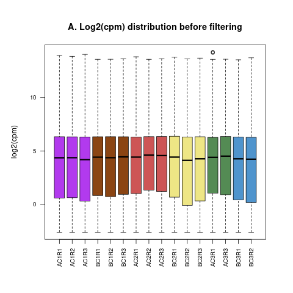

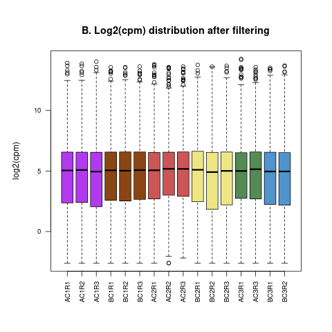

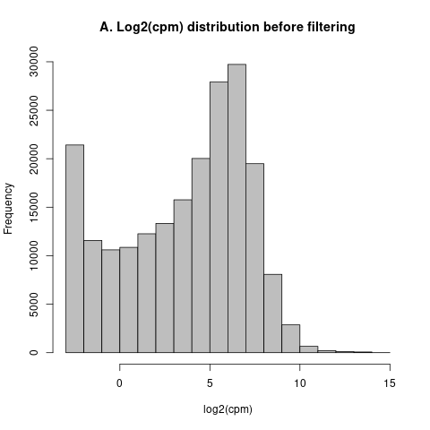

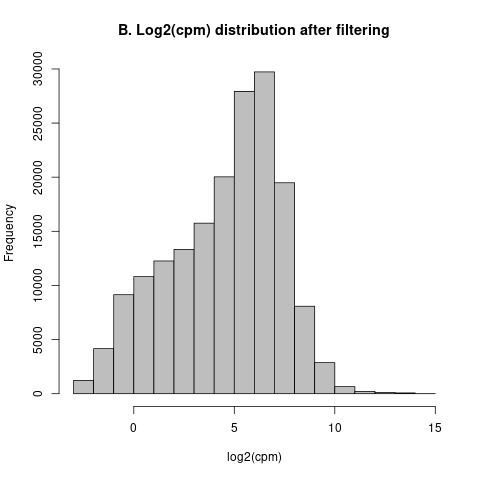

Figure 1: Filtering Data

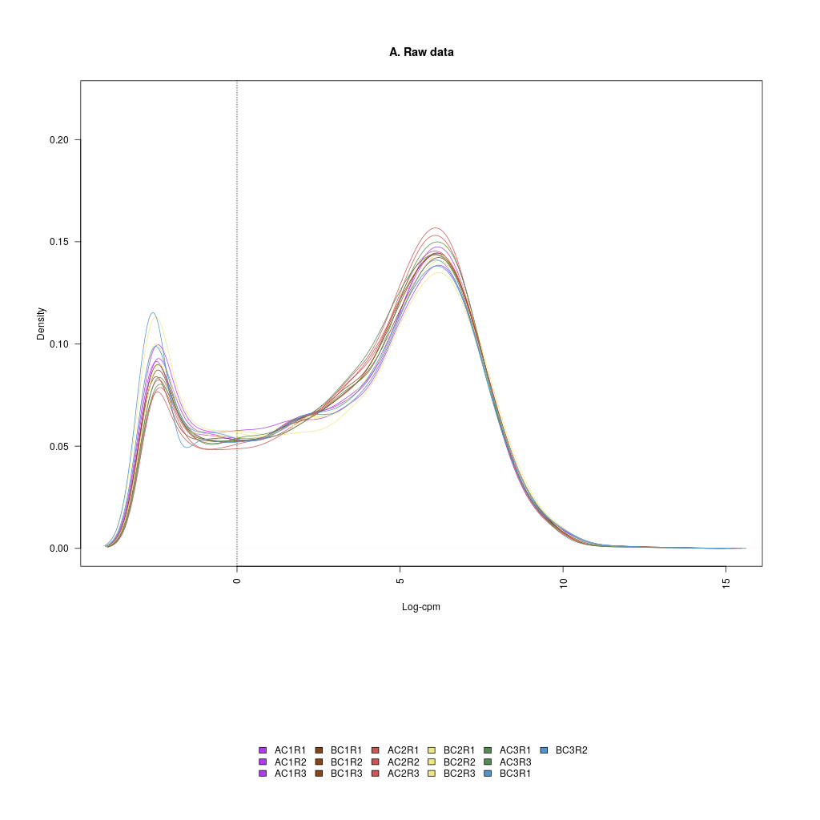

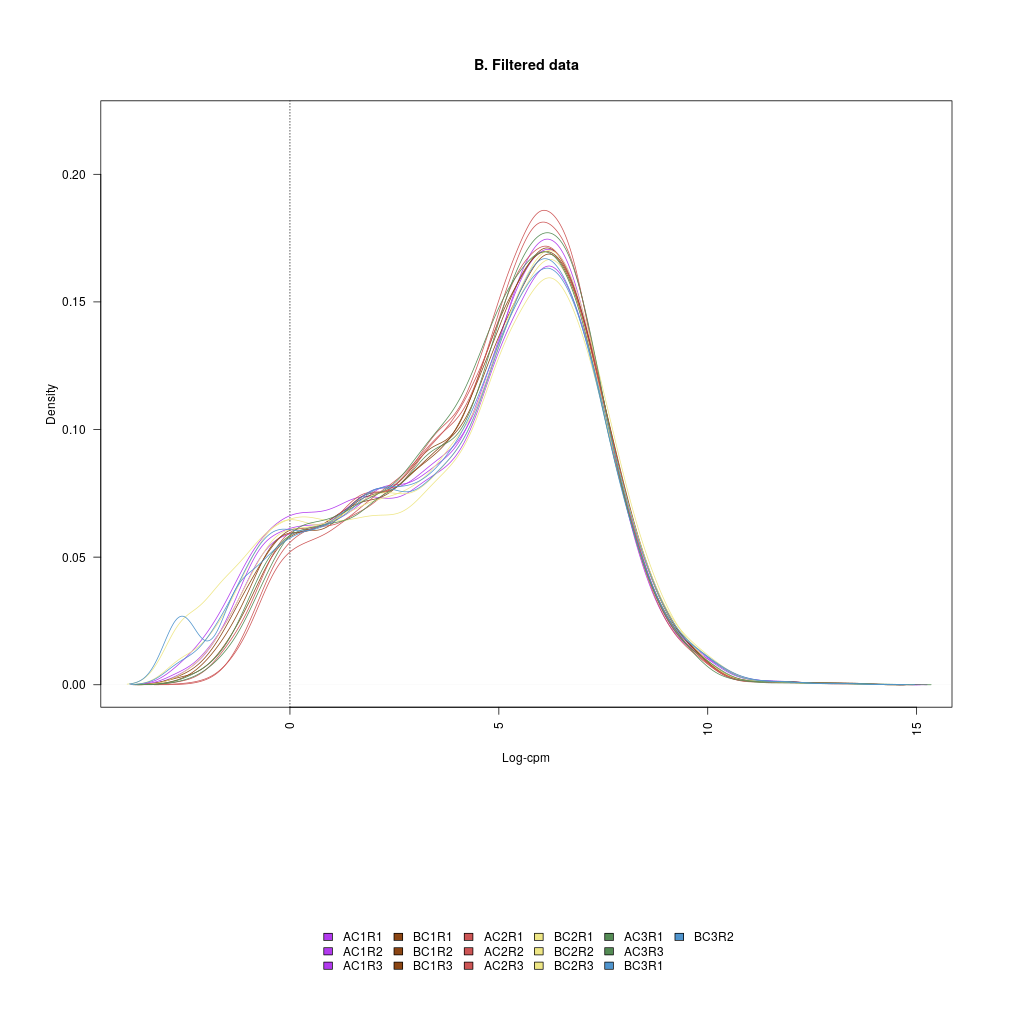

Figure 2: Density Graphes

You notice that the legend of the density graphs is very low compared to the graph. You can correct this with the options `parameters$densinset` which modifies the position of the legend, it is also possible to define the number of columns with `parameters$legendcol`. Finally, restart “GEfilt” function.

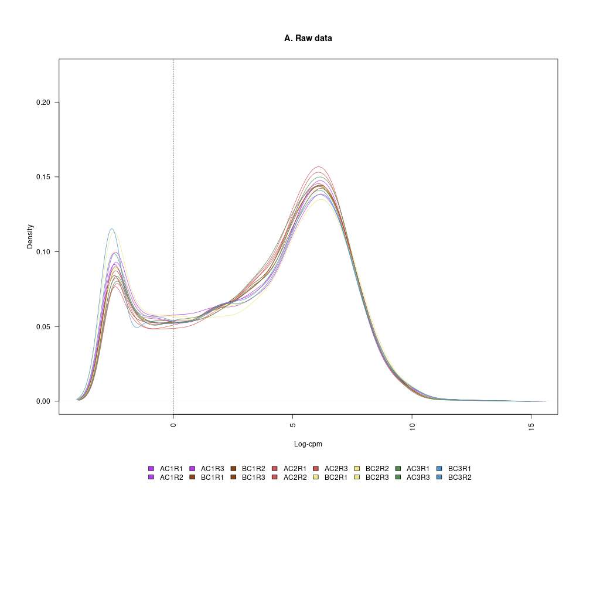

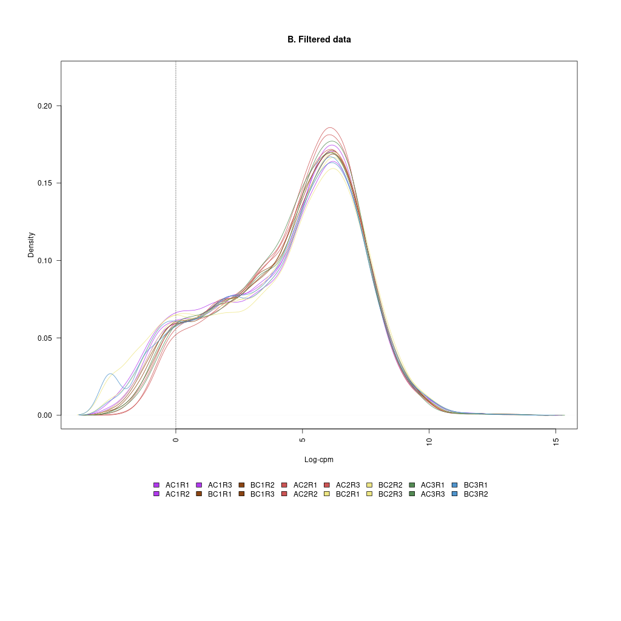

Figure 3: Density Graphes Corrected

```r
# Set position the legend in bottom density graphe
parameters$densinset = 0.20
# Set numbers of column for legends
parameters$legendcol = 8
# run filtering
asko_filt<-GEfilt(data, parameters)
```

# 6 Normalize data

Once the filters have been made, we can proceed to the normalization of the data. At this step, you can generate file with normalize factor values for each sample `parameters$norm_factor=TRUE` and/or generate with normalize counts `parameters$norm_counts=TRUE`.

```r
# run normalization
asko_norm<-GEnorm(asko_filt, asko_data, data, parameters)
```

Normalized data is saved in a structure called here : **asko_norm**. In the folder **DEG_test/images/**, you should find the images representing your data after normalization. Two files are automatically generated because they will be used for co-expression analysis: *“DEG_test_CPMNormCounts.txt”* and *“DEG_test_CPM_NormMeanCounts.txt”*.

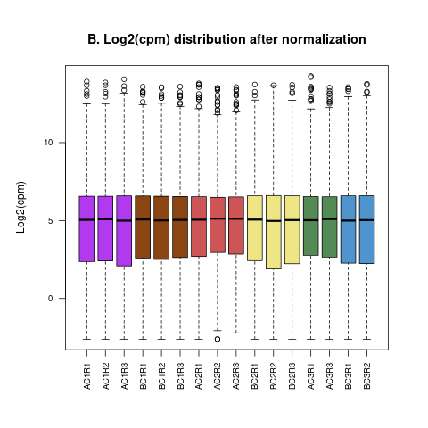

Figure 4: Normalization graphs (barplot)

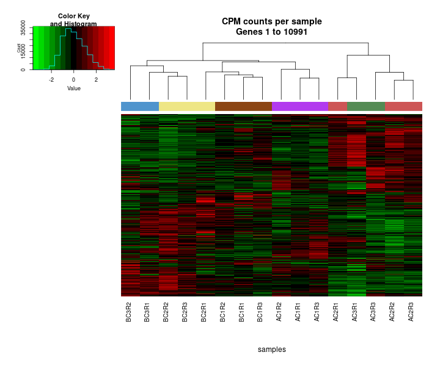

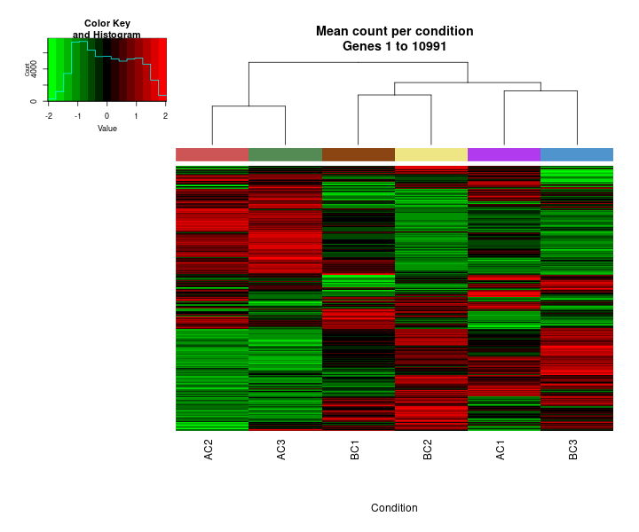

Figure 5: Normalization graphs (heatmap)

# 7 Correlation

From the filtered and normalized data, we can re-correlate the correlation between our samples.

```r
GEcorr(asko_norm,parameters)
```

Several graphics will be saved in the **DEG_test/images/** folder, including MDS and PCA plots. Axis1 vs axis2 differentiate our A and B samples.

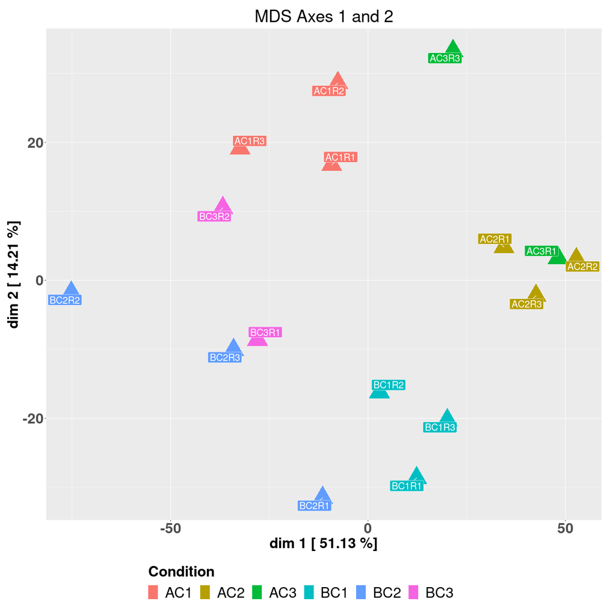

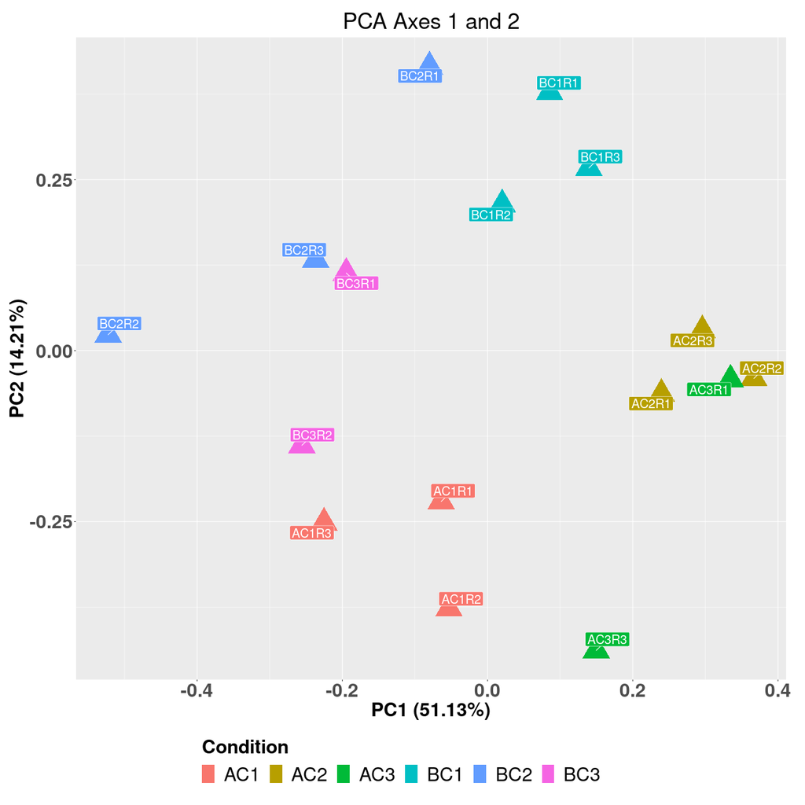

Figure 6: MDS and PCA plots - axis 1 and 2

# 8 DE analysis

The differential expression analysis can be started. We will play with the following parameters:

- FDR threshold value
- logFC threshold value
- normalization method (TMM/RLE/upperquartile/none)
- p-value adjust method (holm/hochberg/hommel/bonferroni/BH/BY/fdr/none)
- GLM method (lrt/qlf)

```r
# FDR threshold
parameters$threshold_FDR = 0.05
# logFC threshold
parameters$threshold_logFC = 0
# normalization method
parameters$normal_method = "TMM"
# p-value adjust method
parameters$p_adj_method = "BH"
# GLM method
parameters$glm = "lrt"
```

You can decide to get the Volcano or Mean-Difference Plots for each contrast:

```r
# Mean-Difference Plot of Expression Data (aka MA plot)
parameters$plotMD = TRUE
# Volcano plot for a specified coefficient/contrast of a linear model
parameters$plotVO = TRUE
```

Once our parameters are defined, we can start the analysis.

```r
# run differential expression analysis
resDEG<-DEanalysis(asko_norm, data, asko_data, parameters)
```

```
##
## AC1<AC2 AC1=AC2 AC1>AC2
##    1747    8358     886
```

```
##
## AC1<AC3 AC1=AC3 AC1>AC3
##    1323    9074     594
```

```
##
## AC2=AC3
##   10991
```

```
##
## BC1<BC2 BC1=BC2 BC1>BC2
##      45   10203     743
```

```
##
## BC1=BC3
##   10991
```

```
##
## BC2<BC3 BC2=BC3 BC2>BC3
##       1   10989       1
```

```
##
## AC1<BC1 AC1=BC1 AC1>BC1
##     635   10055     301
```

```
##
## AC2<BC2 AC2=BC2 AC2>BC2
##    2175    6599    2217
```

```
##
## AC3<BC3 AC3=BC3 AC3>BC3
##    1230    8126    1635
```

```
##
## Create Summary file
```

|  | AC1vsAC2 | AC1vsAC3 | **…** | AC2vsBC2 | AC3vsBC3 | Description |
| --- | --- | --- | --- | --- | --- | --- |
| Gene_000002 | 0 | 0 | **…** | 0 | 0 | hypothetical protei… |
| Gene_000003 | -1 | 0 | **…** | 0 | 0 | histone-lysine n-m… |
| Gene_000004 | 1 | 1 | **…** | -1 | 0 | hypothetical prote… |
| **…** |  |  |  |  |  |  |

You’ll find in **“DEG_test/images/”** directory, les Volcano, MD plots and heatmap for each contrast.

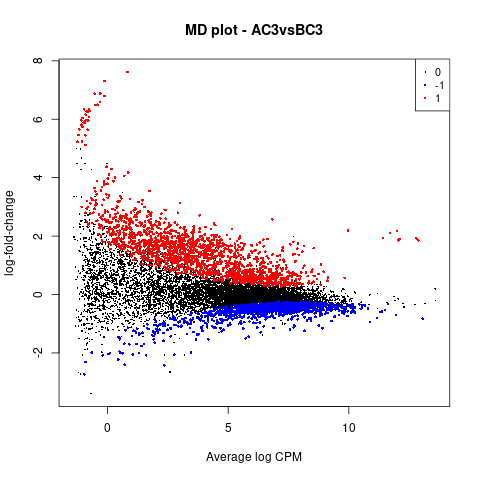

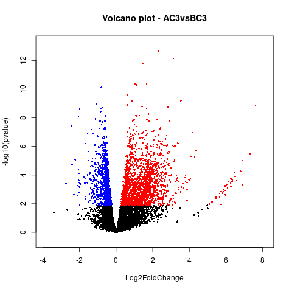

Figure 7: DEanalysis plots

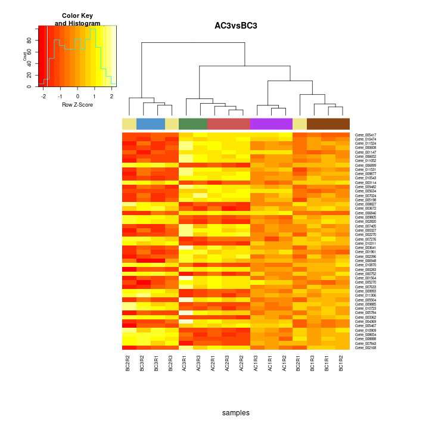

Figure 8: DEanalysis plots

# 9 Basic comparisons

You can compare your lists of differentially expressed genes using two methods: Venn diagrams or Upset graphs. Venn diagrams allow you to compare up to 4 lists while Upset allows you to make wider comparisons. However, if you have too many lists to display the graph may be unreadable.

## 9.1 Venn diagram

To display the Venn diagrams, you need to specify the type of comparison wanted `parameters$VD`:

- “all” : Create VennDiagrams for all differentially expressed genes
- “up” : Create VennDiagrams for gene expressed UP
- “down” : Create VennDiagrams for gene expressed DOWN
- “both” : Create VennDiagrams for gene expressed UP and DOWN (in the same graph)

Next, you must provide a list of the comparisons to display: `parameters$compaVD`. For exemple :

```r
# this create 1 venn diagram
parameters$compaVD=c("Ctrast1-Ctrast2-Ctrast3")
# this create 3 venn diagrams
parameters$compaVD=c("Ctrast1-Ctrast2-Ctrast3",
                     "Ctrast4-Ctrast5-Ctrast6",
                     "Ctrast7-Ctrast8-Ctrast9")
```

Be careful, with the VD=“both” you will only have to provide two contrasts. Example:

```r
# this create 1 venn diagram
parameters$compaVD=c("Ctrast1-Ctrast2")
# this create 3 venn diagrams
parameters$compaVD=c("Ctrast1-Ctrast2",
                     "Ctrast1-Ctrast3",
                     "Ctrast2-Ctrast3")
```

With our data, we will make 3 Venn diagrams for the different types (all, up and down).

```r
parameters$compaVD = c("AC1vsAC2-AC1vsAC3-AC2vsAC3",
                       "BC1vsBC2-BC1vsBC3-BC2vsBC3",
                       "AC1vsBC1-AC2vsBC2-AC3vsBC3")

# graph type "all"
parameters$VD = "all"
VD(resDEG, parameters, asko_data)

# graph type "up"
parameters$VD = "up"
VD(resDEG, parameters, asko_data)

# graph type "down"
parameters$VD = "down"
VD(resDEG, parameters, asko_data)
```

To use the VD=“both” option, we can provide list of two contrasts.

```r
# graph type "both"
parameters$compaVD = c("AC1vsBC1-AC2vsBC2",
                       "AC1vsBC1-AC3vsBC3",
                       "AC2vsBC2-AC3vsBC3")
parameters$VD = "both"
VD(resDEG, parameters, asko_data)
```

All graphs will appear in a folder named **“DEG_test/vennDiagram/”**. Some example of venn diagrams :

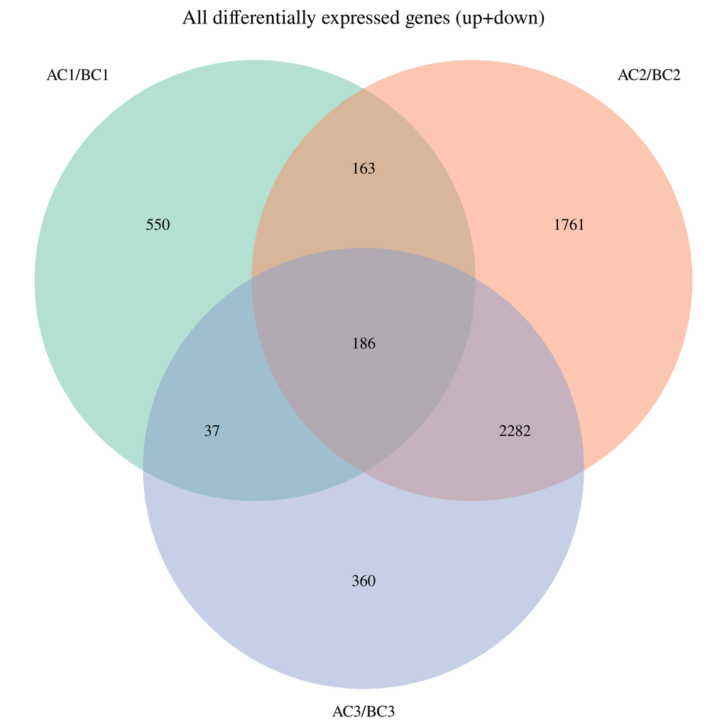

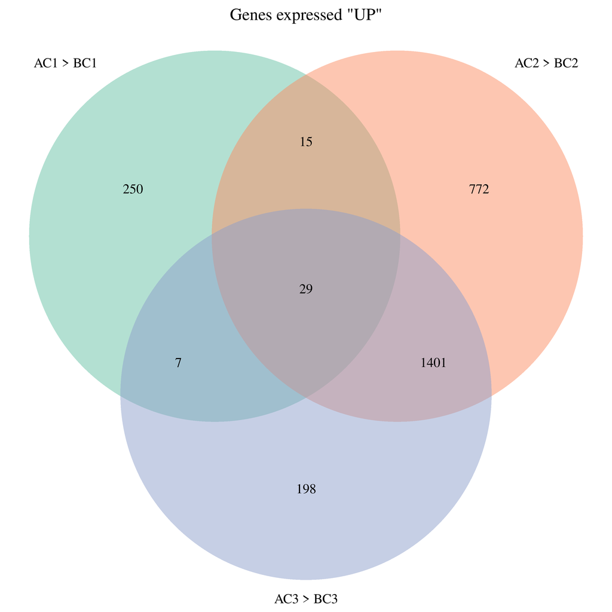

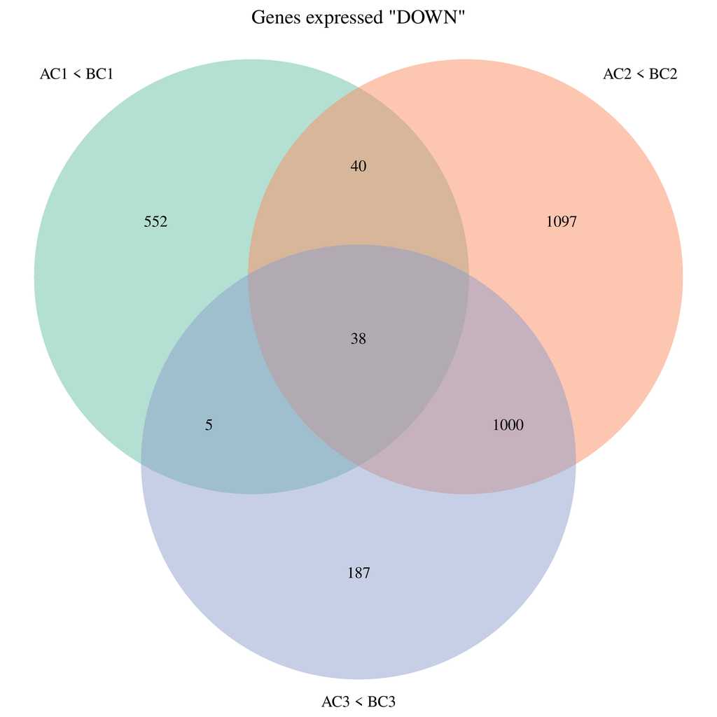

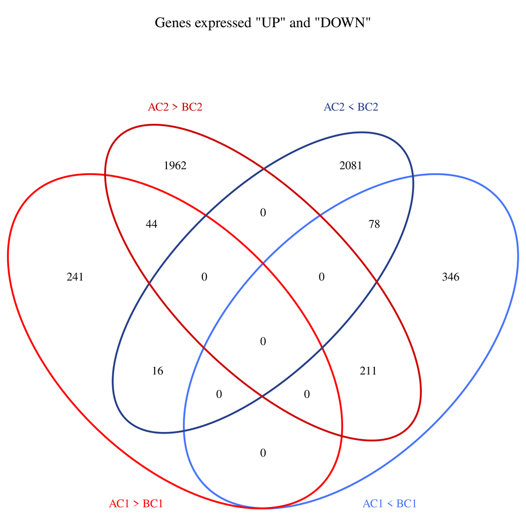

Figure 9: Venn Diagrams

## 9.2 Upset graphs

You can display all contrast, you just need to specify the type of comparison wanted `parameters$upset_basic`: - “all” : Create chart for all differentially expressed genes - “up” : Create chart for gene expressed UP - “down” : Create chart for gene expressed DOWN - “mixed” : Create chart for gene expressed UP and DOWN (in the same graph) - NULL : Don’t make graphs You can display multiples graphs based on list of contrast `parameters$upset_list`, you need to precise the type of comparison `parameters$upset_type`. Example:

```r
# Precise type of comparison: all, down, up, mixed.
parameters$upset_type = "all"

# Give a list of contrast, for example:
# this create 1 graphs
parameters$upset_list = c("Ctrast1-Ctrast2-Ctrast3")
# this create 3 graphs
parameters$upset_list = c("Ctrast1-Ctrast2-Ctrast3",
                          "Ctrast4-Ctrast5-Ctrast6",
                          "Ctrast1-Ctrast2-Ctrast3-Ctrast4-Ctrast5")
```

With our data, we will make several upset charts for the different types (all, up, down and mixed), with all contrast and list of contrast.

```r
parameters$upset_list = c("AC1vsAC2-AC1vsAC3-AC2vsAC3",
                          "BC1vsBC2-BC1vsBC3-BC2vsBC3",
                          "AC1vsBC1-AC2vsBC2-AC3vsBC3")

# graphs type "all"
parameters$upset_basic = "all" # all contrast
parameters$upset_type = "all"  # list of contrast
UpSetGraph(resDEG, data, parameters)

# graphs type "mixed"
parameters$upset_basic = "mixed" # all contrast
parameters$upset_type = "mixed"  # list of contrast
UpSetGraph(resDEG, data, parameters)

# graphs type "up"
parameters$upset_basic = "up" # all contrast
parameters$upset_type = "up"  # list of contrast
UpSetGraph(resDEG, data, parameters)

# graphs type "down"
parameters$upset_basic = "down" # all contrast
parameters$upset_type = "down"  # list of contrast
UpSetGraph(resDEG, data, parameters)
```

An **“DEG_test/UpSetR_graphs/”** directory will be created with two subdirectories **“DEG_test/ UpSetR_graphs/Global_upset/”** and **“DEG_test/UpSetR_graphs/ Subset_upset/”**.  
Some example of upset graphs (from subset *“AC1vsBC1-AC2vsBC2-AC3vsBC3”*):

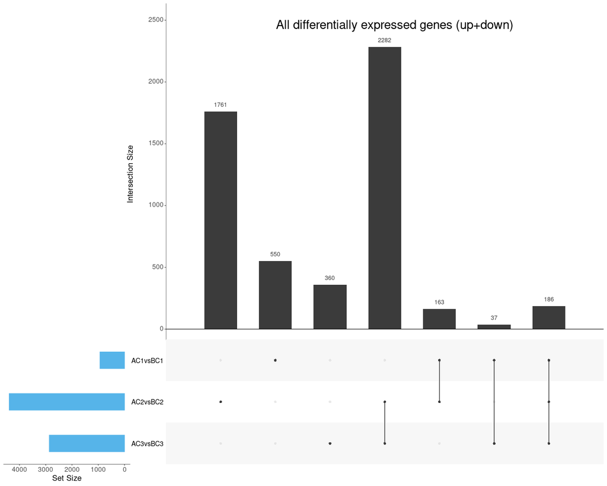

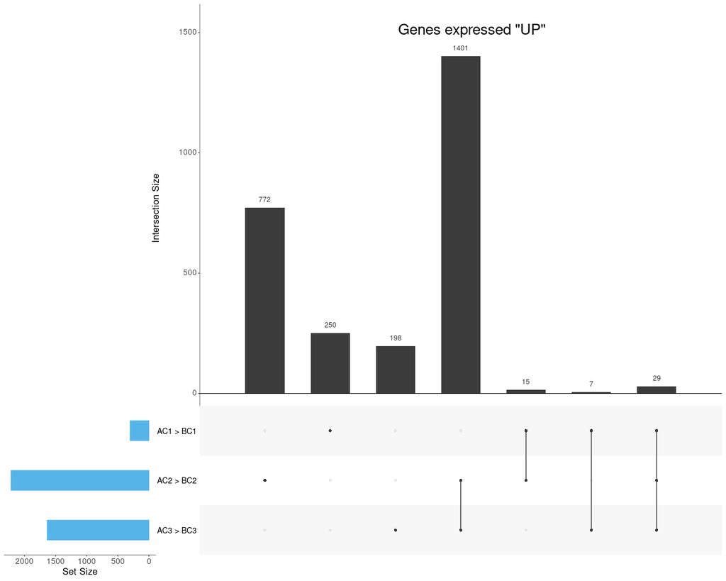

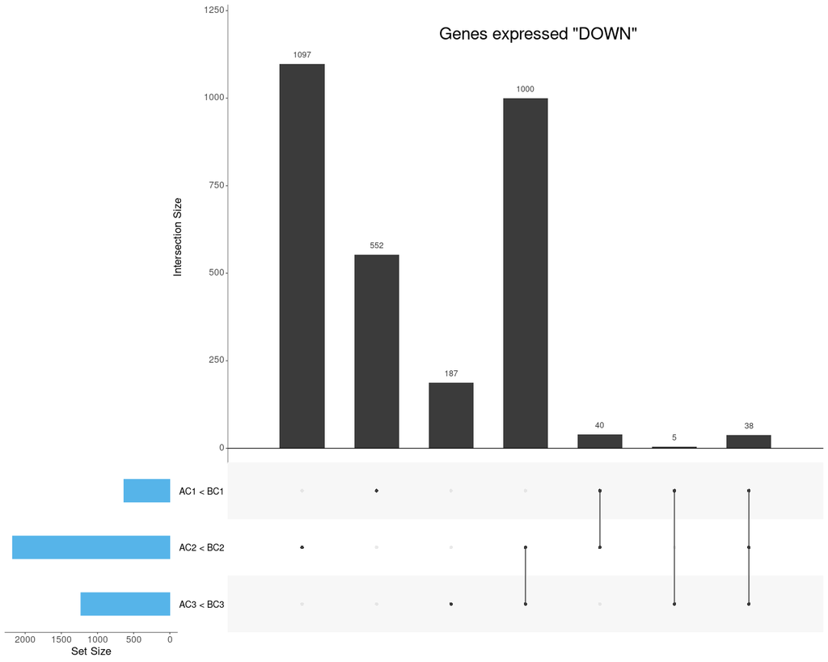

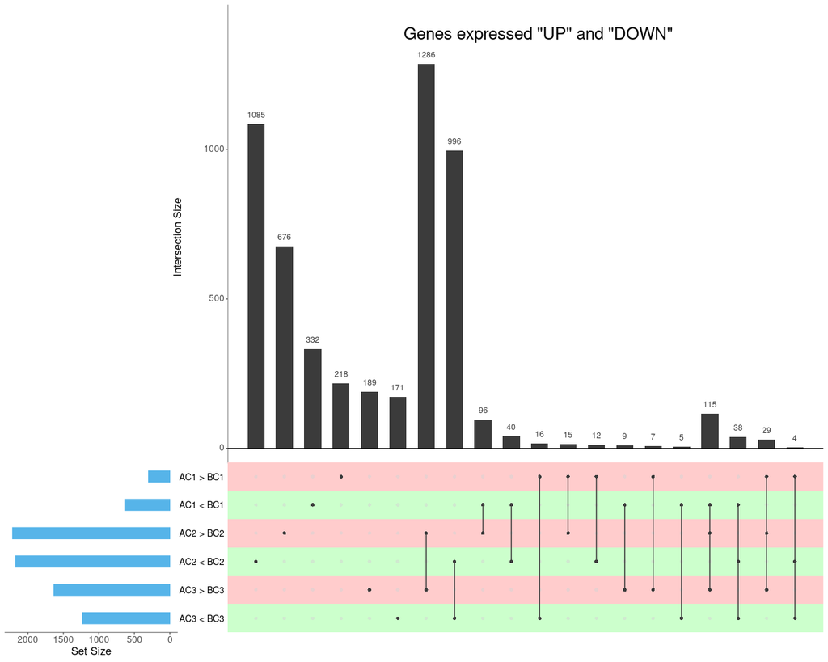

Figure 10: UpsetR Graphs

# 10 GO Enrichment Analysis

We uses the GOs annotations file to perform enrichment analysis on differentially expressed gene. For this, you define :

- `parameters$GO_threshold` the significant threshold used to filter p-values
- `parameters$GO_max_top_terms` the maximum number of GO terms plot
- `parameters$GO_min_num_genes` the minimum number of genes for each GO terms
- `parameters$GO` gene set chosen for analysis ‘up’, ‘down’, ‘both’ (up+down)
- `parameters$GO_algo` algorithms for runTest function (“classic”, “elim”, “weight”, “weight01”, “lea”, “parentchild”)
- `parameters$GO_stats` statistical tests for runTest function (“fisher”, “ks”, “t”, “globaltest”, “sum”, “ks.ties”)
- `parameters$Ratio_threshold` the min ratio for display GO in graph

After that, we can run Go enrichment analysis:

```r
# Parameters
parameters$GO_threshold = 0.05
parameters$GO_max_top_terms = 10
parameters$GO_min_num_genes = 10
parameters$GO = "both"
parameters$GO_algo = "weight01"
parameters$GO_stats = "fisher"
parameters$Ratio_threshold = 1

# run analysis
GOenrichment(resDEG, data, parameters)
```

An **“DEG_test/GO_images/”** directory will be created with all GO images and tables of statistics. Example of graph:

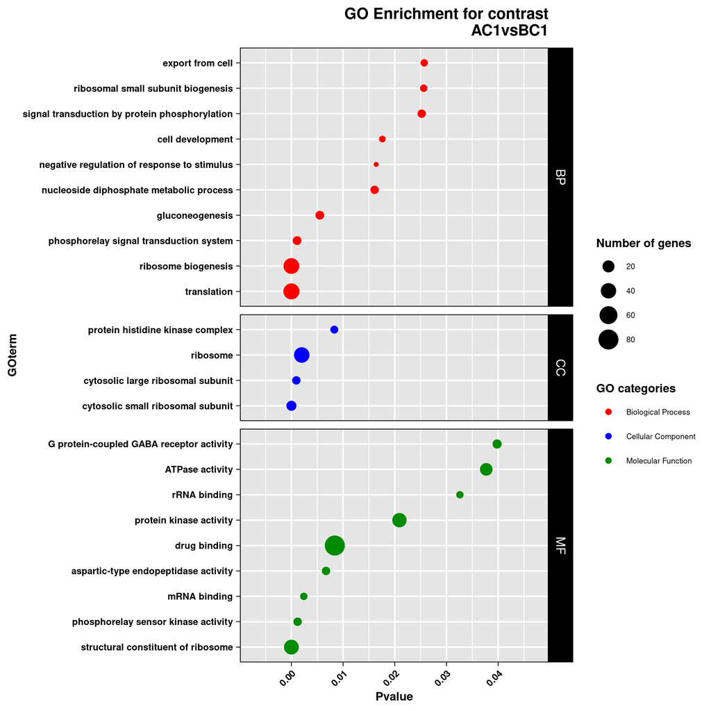

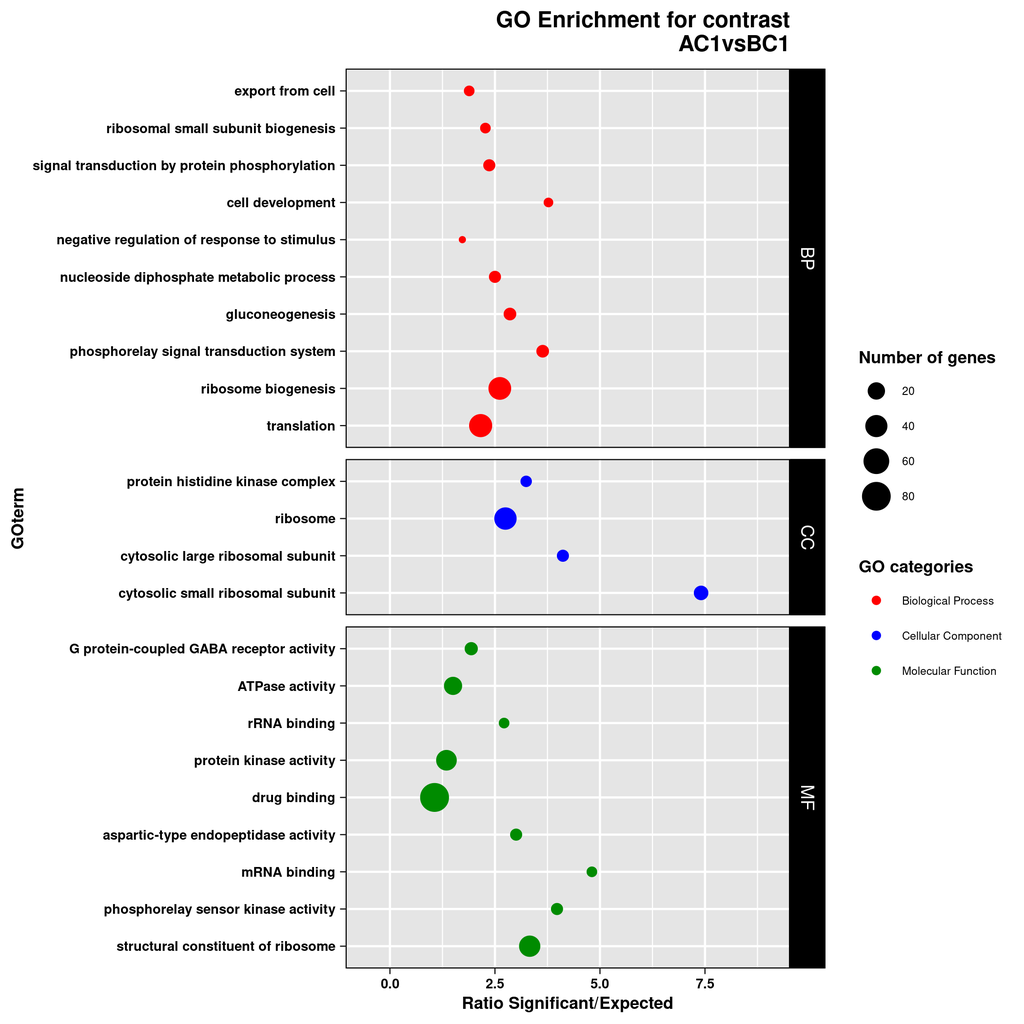

Figure 11: GO Enrichment graphs

Example of one statistical table:

| GO.ID | Term | Annotated | Significant | Expected | statisticTest | Ratio | GO_cat |
| --- | --- | --- | --- | --- | --- | --- | --- |
| GO:0003735 | structural const… | 135 | 36 | 10.81 | 4.6e-11 | 3.3302497687 | MF |
| GO:0000155 | phosphorelay sen… | 22 | 7 | 1.76 | 0.0012 | 3.9772727272 | MF |
| GO:0003729 | mRNA binding | 13 | 5 | 1.04 | 0.0024 | 4.8076923076 | MF |
| GO:0036094 | small molecule b… | 1327 | 105 | 106.24 | 0.0038 | 0.9883283132 | MF |
| … |  |  |  |  |  |  |  |

Explications of some columns:

- **Annotated:** number of genes in your genome are annotated with the GO-term.
- **Significant:** number of genes belonging to your input which are annotated with the GO-term.
- **Expected:** show an estimate of the number of genes a node of size Annotated would have if the significant genes were to be randomly selected from the gene universe.
- **statisticTest:** result of fisher test

# 11 Coexpression